# Разделение экологических ниш между тремя видами лебедей

## Вставка в материал и методику

Для оценки влияния факторов на численность лебедей и выявления различий в использовании пространства тремя видами (Sp1, Sp2, Sp3) мы применили обобщенные аддитивные модели (GAM, generalized additive models). Данный подход позволяет моделировать нелинейные зависимости между предикторами и откликом без априорного задания функциональной формы связи (Wood, 2017).

В качестве зависимой переменной выступало число особей каждого вида, учтенное на точке наблюдения (N). Учитывая, что данные представляют собой счетные величины с избыточной дисперсией, мы использовали семейство отрицательного биномиального распределения, которое лучше подходит для таких данных по сравнению с распределением Пуассона (Zuur et al., 2009).

Модель включала следующие фиксированные эффекты:

Год (Year) – для учета межгодовой динамики численности. Поскольку тренды могли различаться у разных видов, сглаживающий сплайн (smooth spline) подбирался отдельно для каждого вида.

Глубина (Depth) и расстояние от берега (Dist) – ключевые факторы, определяющие доступность кормовых биотопов. Предварительный анализ выявил высокую корреляцию между этими переменными, поэтому для избежания мультиколлинеарности и потери информации мы использовали двумерный сплайн. Это позволяет моделировать совместное влияние этих факторов на численность лебедей. Поскольку характер использования акватории мог зависеть как от вида, так и от ледовой обстановки, двумерные сплайны подбирались отдельно для каждой комбинации вида и ледовой обстановки.

Вид лебедя (Species) – категориальный предиктор с тремя градациями (Sp1, Sp2, Sp3), позволяющий оценить общие различия в численности между видами.

Ледовая обстановка (Ice) – бинарный фактор, характеризующий наличие или отсутствие ледового покрова в момент учета (градации: Ice_cover – ледовый покров, No_ice – открытая вода).

Для учета псевдоповторности, обусловленной проведением повторных учетов на одних и тех же станциях (Site), в модель был включен случайный эффект точки наблюдения в виде сглаживающего члена с штрафом, что эквивалентно случайному интерцепту в смешанных моделях (Wood, 2017).

Оценка параметров модели проводилась методом ограниченного максимального правдоподобия (REML), который обеспечивает наилучший компромисс между смещением и дисперсией оценок сглаживания (Wood, 2011). Модель была реализована в среде R версии 4.5.2 (R Core Team, 2025) с использованием пакета mgcv (Wood, 2017). Для проверки валидности построенной модели и визуализации результатов применяли функции из пакета gratia (Simpson, 2024)

Литература:

R Core Team (2025). *R: A Language and Environment for Statistical Computing*. R Foundation for Statistical Computing, Vienna, Austria. https://www.R-project.org/.

Simpson G (2024). “gratia: An R package for exploring generalized additive models.” *Journal of Open Source Software*, *9*(104), 6962. doi:10.21105/joss.06962 https://doi.org/10.21105/joss.06962.

Wood S.N. (2017) Generalized Additive Models: An Introduction with R. 2nd edn. Chapman and Hall/CRC.

Wood S.N. (2011) Fast stable restricted maximum likelihood and marginal likelihood estimation of semiparametric generalized linear models. Journal of the Royal Statistical Society (B) 73(1):3-36.

Zuur A.F. et al. (2009) Mixed Effects Models and Extensions in Ecology with R. Springer.

## Вот так выглядит модель

```r
library(mgcv)

Mod <- gam(N ~ s(Year, by = Species, k = 5) +
             s(Dist, Depth,  by = interaction(Species, Ice), k = 10) +
             Species + Ice +
             s(Site, bs = "re", k = length(unique(dat2$Site))),
             data = dat2,
             family = nb(),
             method = "REML")
```

Вот summary подобранной модели

Таблица 1. Результаты подгонки обобщенной аддитивной модели (GAMM) для оценки влияния факторов на пространственное распределение трех видов лебедей (Sp1, Sp2, Sp3) в ледовый и безледовый периоды Table 1. Fitting results of the generalized additive mixed model (GAMM) assessing the effects of environmental factors on the spatial distribution of three swan species (Sp1, Sp2, Sp3) during ice-covered and ice-free periods

| Smoother term | edf | ref.df | F | p-value |
| --- | --- | --- | --- | --- |
| s(Year):SpeciesSp1 | 3.6 | 3.9 | 33.5 | 0.000 |
| s(Year):SpeciesSp2 | 3.7 | 3.9 | 110.9 | 0.000 |
| s(Year):SpeciesSp3 | 3.9 | 4.0 | 160.9 | 0.000 |
| s(Dist,Depth):interaction(Species, Ice)Sp1.Ice_cover | 2.0 | 2.0 | 4.5 | 0.107 |
| s(Dist,Depth):interaction(Species, Ice)Sp2.Ice_cover | 3.7 | 4.3 | 8.7 | 0.085 |
| s(Dist,Depth):interaction(Species, Ice)Sp3.Ice_cover | 4.0 | 4.9 | 4.5 | 0.470 |
| s(Dist,Depth):interaction(Species, Ice)Sp1.No_ice | 7.4 | 8.3 | 100.8 | 0.000 |
| s(Dist,Depth):interaction(Species, Ice)Sp2.No_ice | 6.5 | 7.2 | 120.3 | 0.000 |
| s(Dist,Depth):interaction(Species, Ice)Sp3.No_ice | 7.4 | 8.0 | 184.1 | 0.000 |
| s(Site) | 13.5 | 20.0 | 225.5 | 0.000 |

Что здесь важно увидеть.

1. У всех видов многолетняя есть выраженная динамика численности. Ниже я приведу графики.
2. В ледовый период отчетливых паттернов привязки к градиенту Depth-Distance не выявляется ни у одного из видов.
3. В безледный период у всех трех видов наблюдается статистически значимая связь с градиентом Depth-Distance.

## Визуализации

### Многолетняя динамика

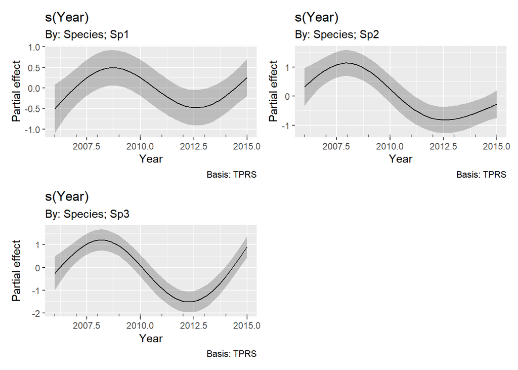

Колебания численности есть, но разбираться в них пока не будем.

### Разделение экологических ниш в градиенте Depth-Distance в безледный период

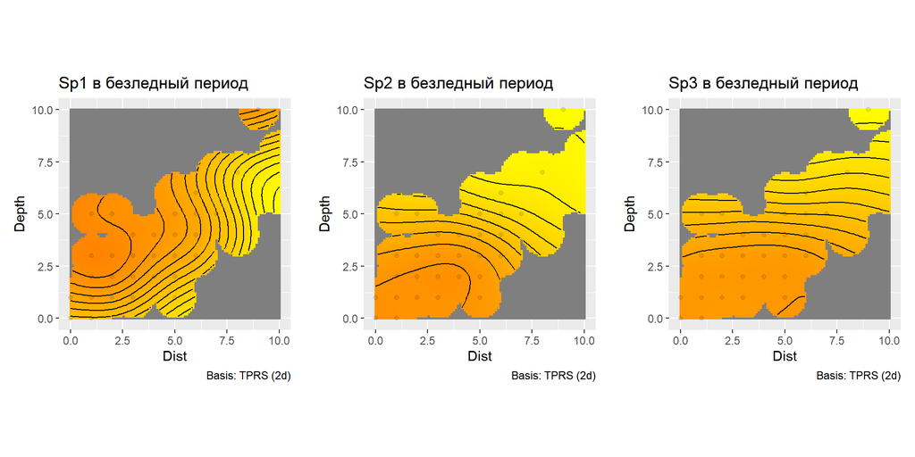

Распределение трех видов лебедей в гардиенте глубины и удаленности от берега. Чем краснее заливка, тем больше обилие.

Видно, что Sp1 держится на большей глубине и при этом может уходить достаточно далеко от берега. Sp2 и Sp3 держатся близко от берега и на малой глубине. При этом, Sp2 смотрится как самый стенобионтный вид, он не заплывает далеко от берега, в то время как Sp3 может заходить дальше.

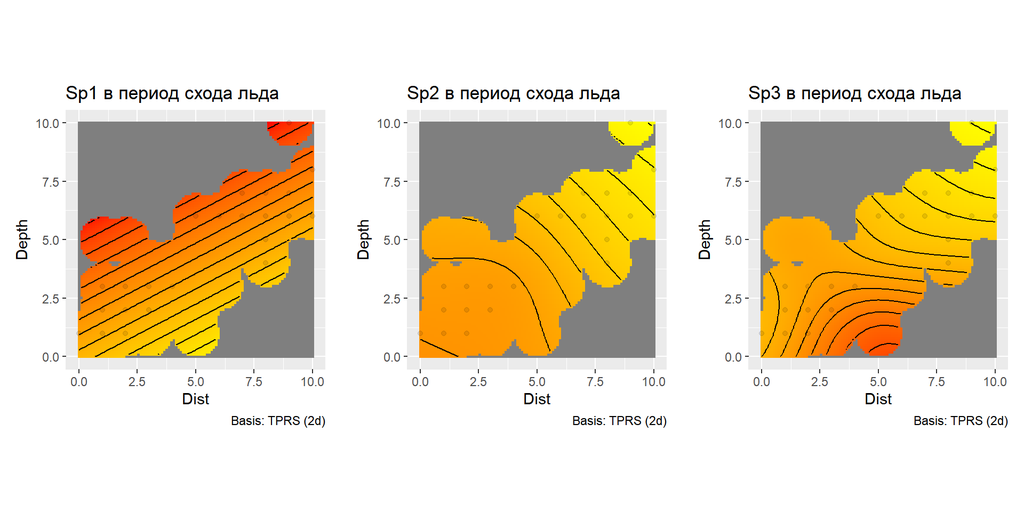

Распределение трех видов лебедей в гардиенте глубины и удаленности от берега в период схода льда. Чем краснее заливка, тем больше обилие.

## Дополнения

**1. можно ли показать, что кликун и тундровый лебедь в сборе корма строго ограничены изобатой 1,5 м (или около того).**

Сергей, здесь можно показать вот такой совсем простой рисунок.

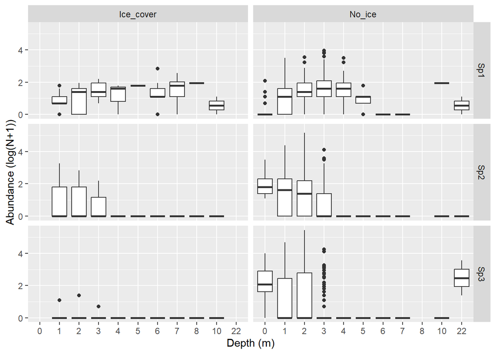

**2. В части касающейся первого периода со льдом (где все сложно) все лебеди держались на двух кормовых биотопах — первых полыньях на самых мелководных участках у берега и на глубоководной акватории за линией припая. Можем ли показать, что тундровый лебедь и кликун были только на полыньях, а шипун — как на полыньях так и на глубокой воде за припаем? Это весьма важно.**

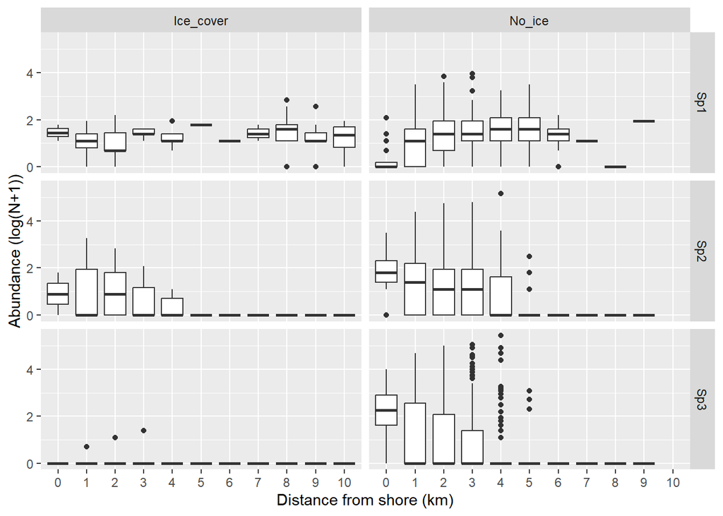

Не показывает ли эта картинка именно это? Здесь видно, что в ледовый период шипун в ненулевых количествах сидит везде. Ненулевые медианы численности (точнее логарфма численности) у кликуна приходятся на прибрежные участки.Те редкие встречи тундряного, которые были в ледовый период, были только в прибрежной части.

Возможно эту визуализацию можно улучшить, например, введя классификацию полыней. Тапа, “маленькая прибрежная полынья” “большая прибрежная полынья”, “за пределами зоны припая”. Или что-то подобное. Есть возможность такую колонку сделать в файле с первичкой.

### Дополнение 2

Сергей! Предлагаю вот такую простую визуализацию, характеризующую распределение численностей видов по двум типам свободной воды в ледовый период. Это просто пай-чарты, отражающие соотношение средних численностей лебедей в двух типах свободной воды в период таяния льда. По мне так здесь все отчетливо видно.

```
## # A tibble: 6 × 3
## # Groups:   Feeding_place [2]
##   Feeding_place                             Species Mean_abund
##   <chr>                                     <fct>        <dbl>
## 1 coastal shallow ice floes                 Sp1          2.62
## 2 coastal shallow ice floes                 Sp2          2.92
## 3 coastal shallow ice floes                 Sp3          0.113
## 4 remote deep-water areas near the ice edge Sp1          4.32
## 5 remote deep-water areas near the ice edge Sp2          0.15
## 6 remote deep-water areas near the ice edge Sp3          0
```

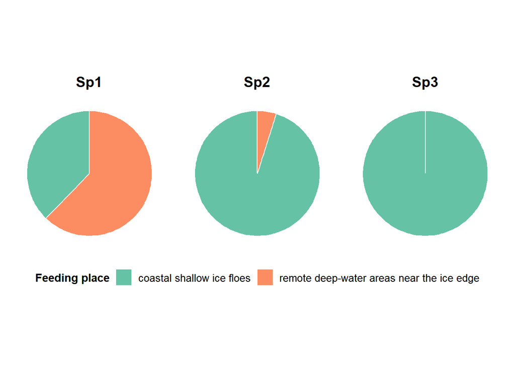

Но если важно как-то учесть еще и расстояние, то тут появится проблема, так как каждый из типов полыней очень жестко связан с глубиной и расстоянием до берега. То есть это практически одно и то же.

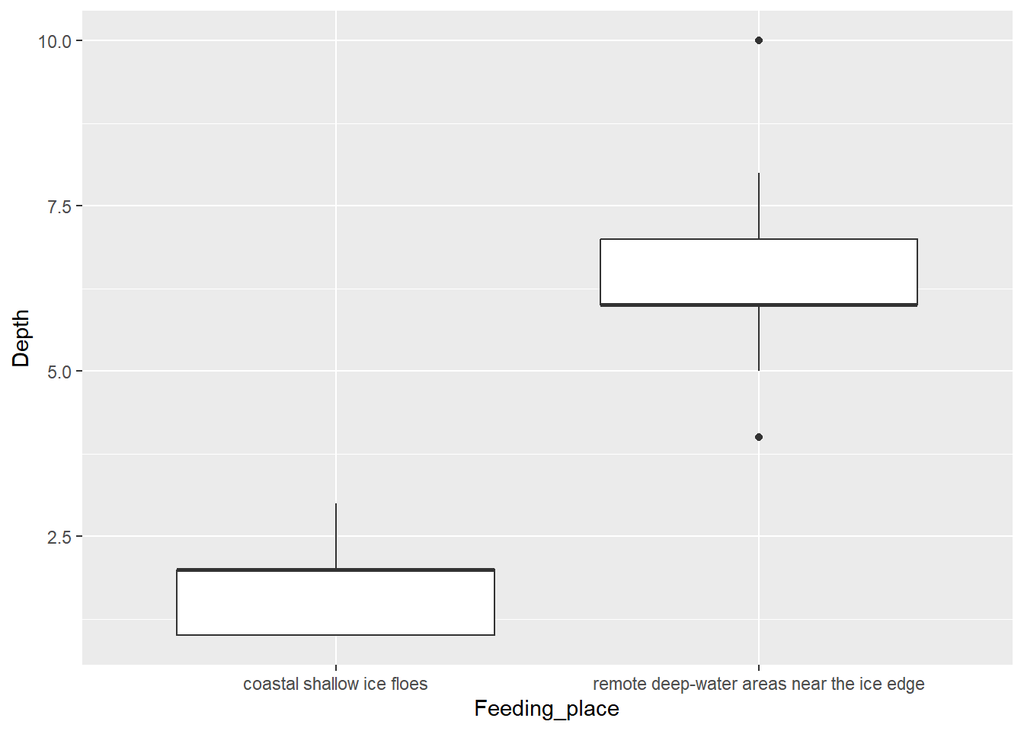

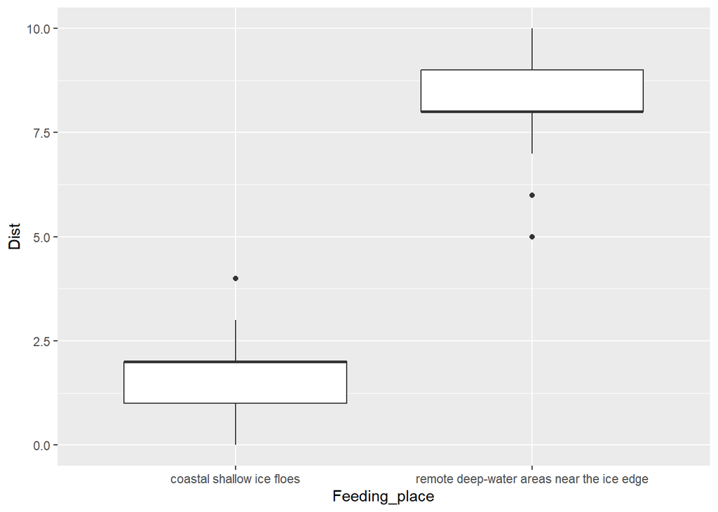